# Filling the Gaps

Oral Healthcare in Chautauqua County

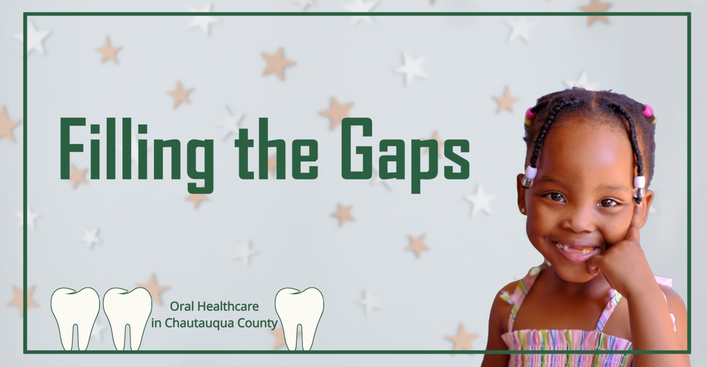

A data visualization prepared by:

*(Best viewed on a desktop monitor, but suitable for smaller displays.)*

[figure not shown]

[figure not shown]

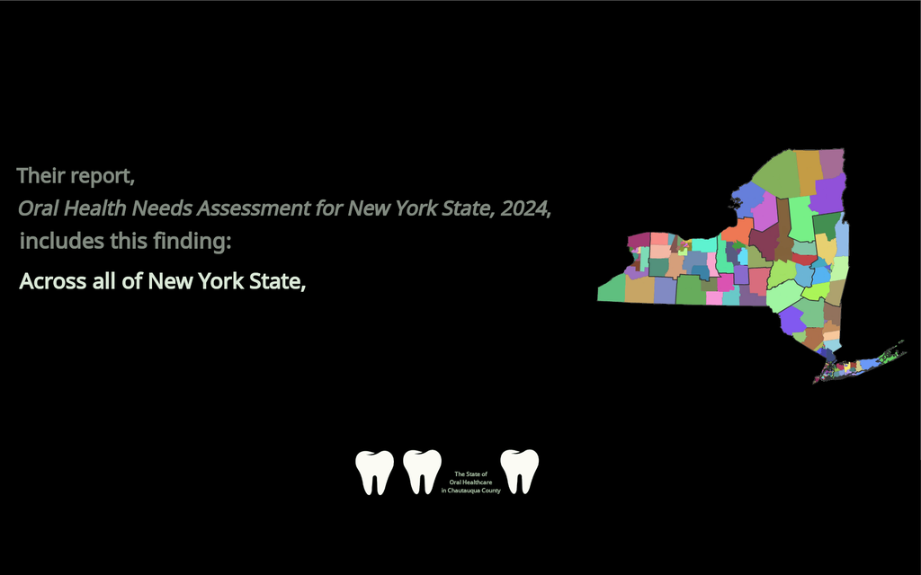

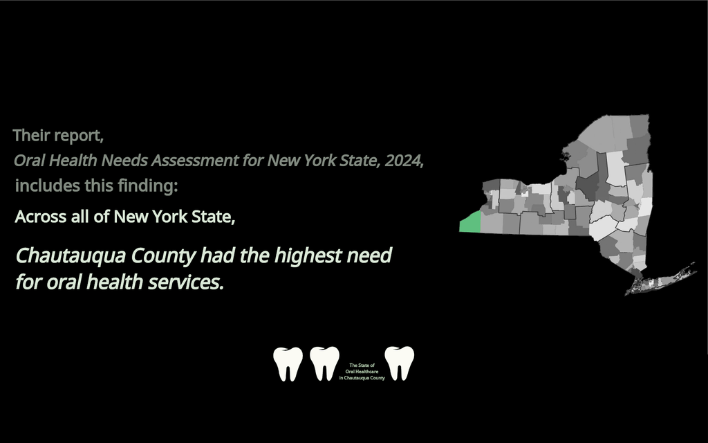

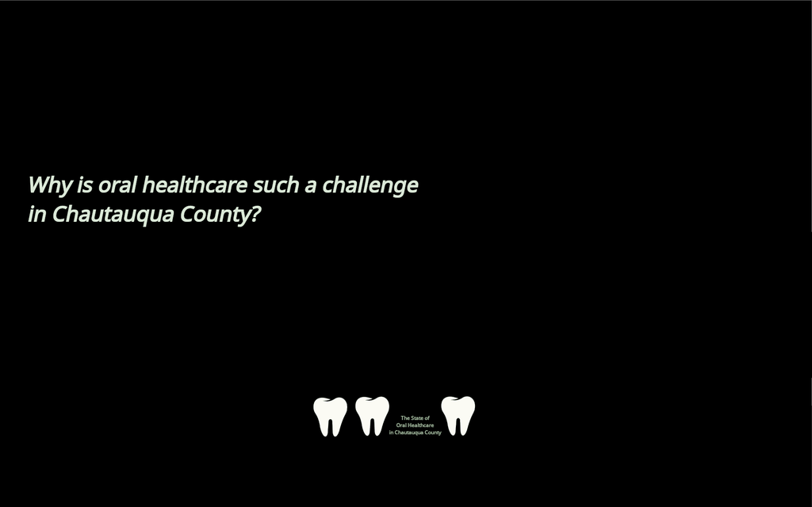

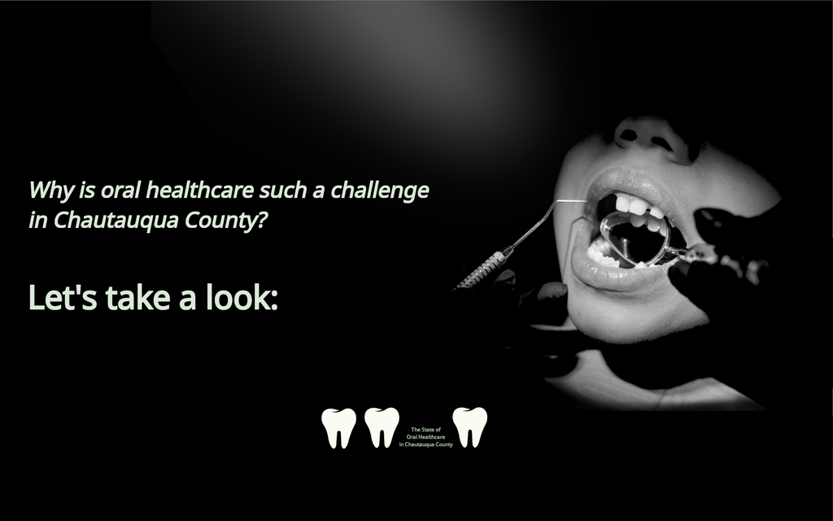

**Three major barriers directly impact oral healthcare in our county:**

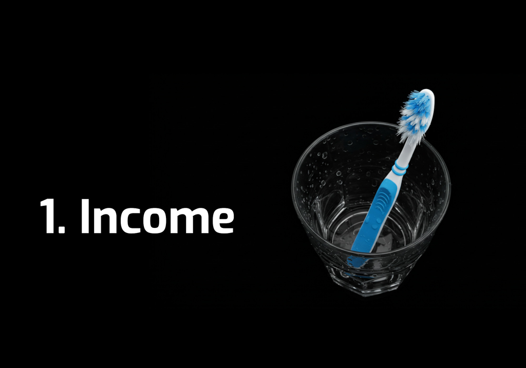

Another study published by the Center for Health Workforce Studies in 2024 examined barriers faced by New York State residents in accessing oral health services.

One of the socioeconomic characteristics most strongly associated with not obtaining needed oral health services was **household income less than $50,000.**

*Barely half* *(51.1%)* of survey respondents from households with less than $50,000 annual income said they always received needed oral health services.

Data from our own county suggests that income may be *even more* of a barrier here.

In the first quarter of 2025, the Chautauqua County Health Department, along with community partners, conducted a community health survey.

Of the respondents who reported a household income less than $50,000 (n=577), **70%** reported at least one barrier that kept them or someone in their household from getting dental care that was needed or recommended.

The most common barrier…

… and the second most common barrier…

… were both related to cost.

[figure not shown]

[figure not shown]

[figure not shown]

[figure not shown]

The data suggests that household income below $50,000  
is more often than not associated with inadequate dental care.  
This income barrier is *especially* relevant for Chautauqua County:

The U.S. Census Bureau reports the percentage of households in each county that have incomes less than $50,000.

Three counties in eastern New York State have fewer than **20%** of their households with incomes below $50,000.

A smattering of counties in the state have fewer than **30%** of their households with annual incomes less than $50K.

Here are the counties with less than **35%** of their households with incomes below $50,000.

The vast majority of New York State counties have *at most **40%*** of households with incomes below $50,000.

Only three counties in New York State have *more than **42%*** of their households with incomes less than $50K.  
Chautauqua County is one of them.

In fact, there’s only one county in the state (Bronx County) with a greater percentage of households with incomes below $50,000.

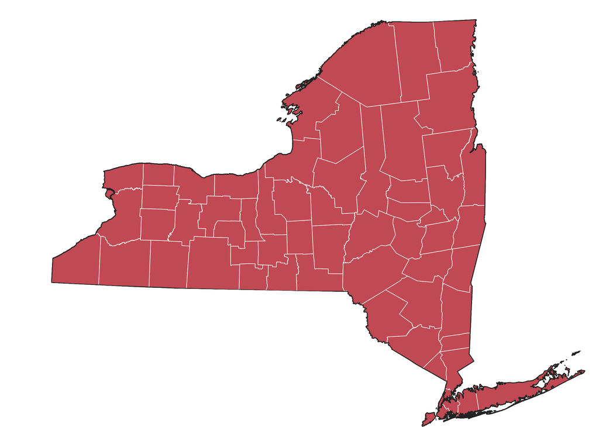

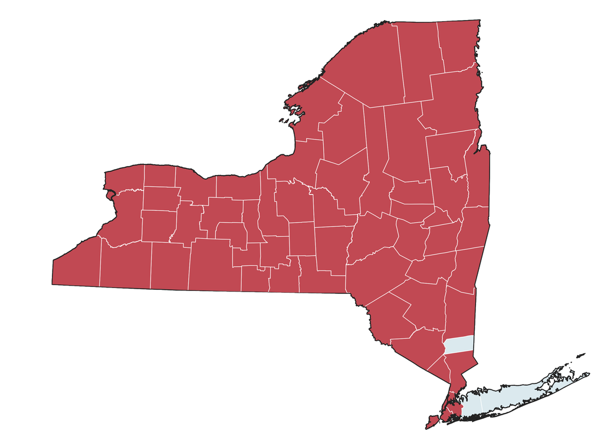

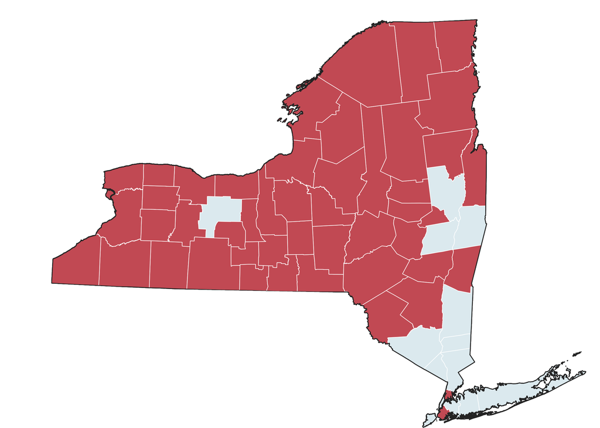

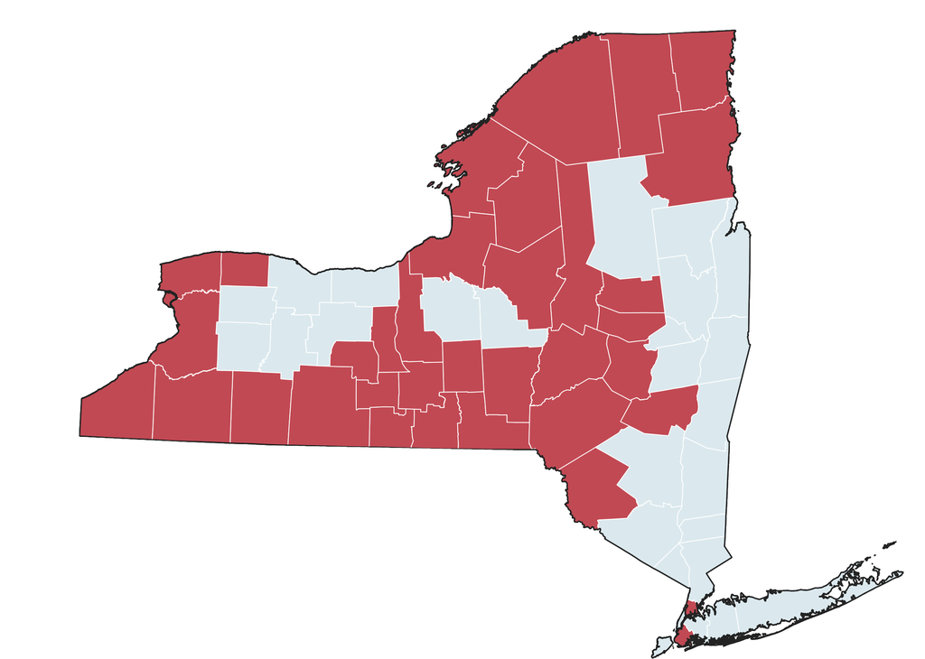

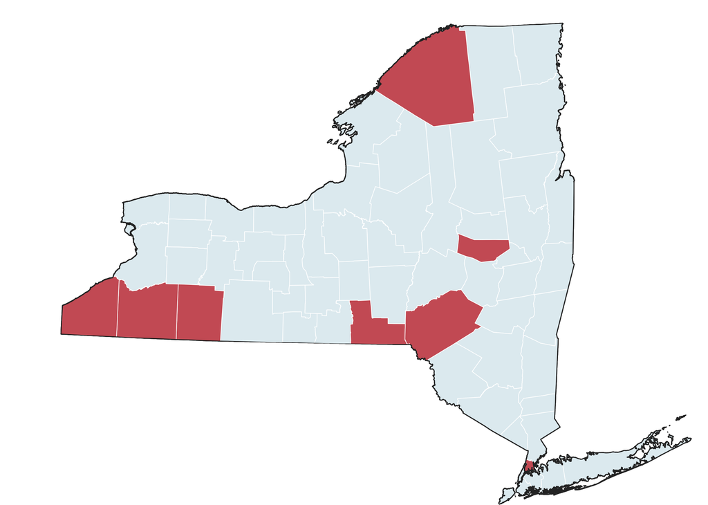

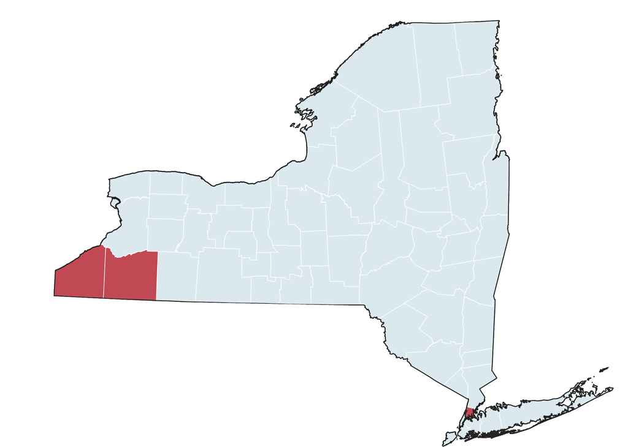

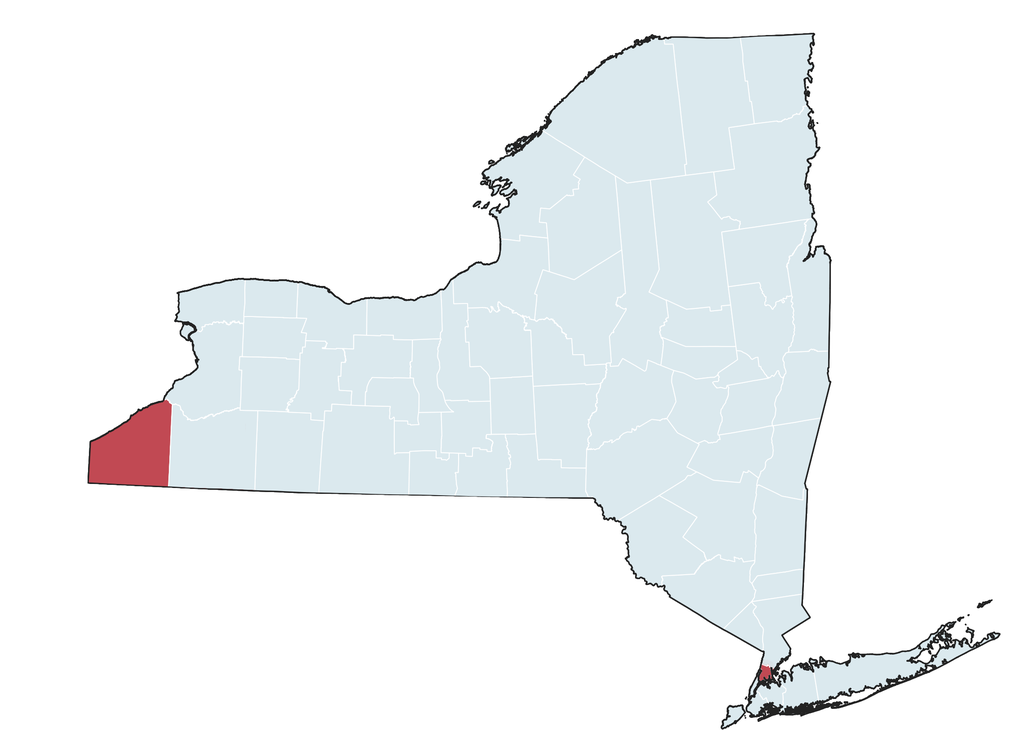

*To pull all of this together:*  
Statewide, just under  
*one-third* of households have incomes below $50,000.

Of those residents, *almost half* report that they did not always receive needed dental care.

In Chautauqua County, a *much* higher percentage of households have incomes less than $50,000…

… *AND* the percentage of those residents who do not always receive needed dental care is higher.

The data suggests that  
**37,000 - 38,000** Chautauqua County residents residing in households with less than $50,000 annual income may not be receiving the dental care they need.

And this is the impact on dental care of only *one* barrier: income.  
There are others.

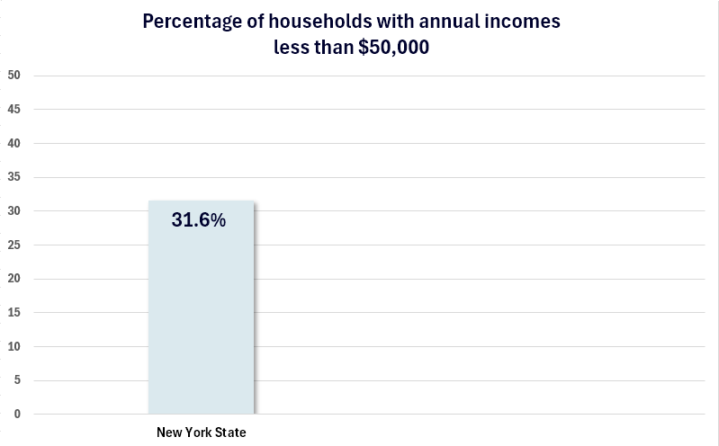

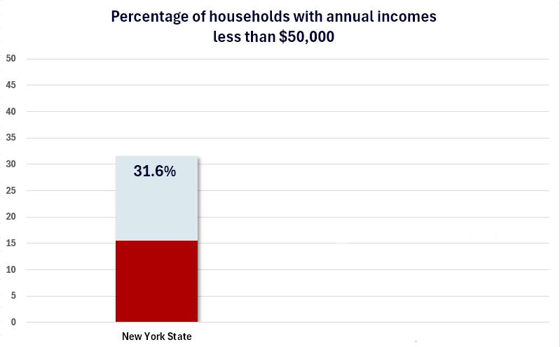

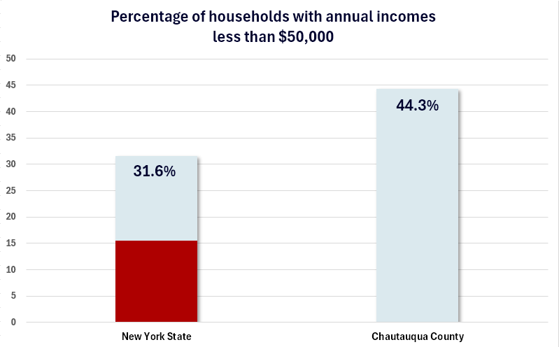

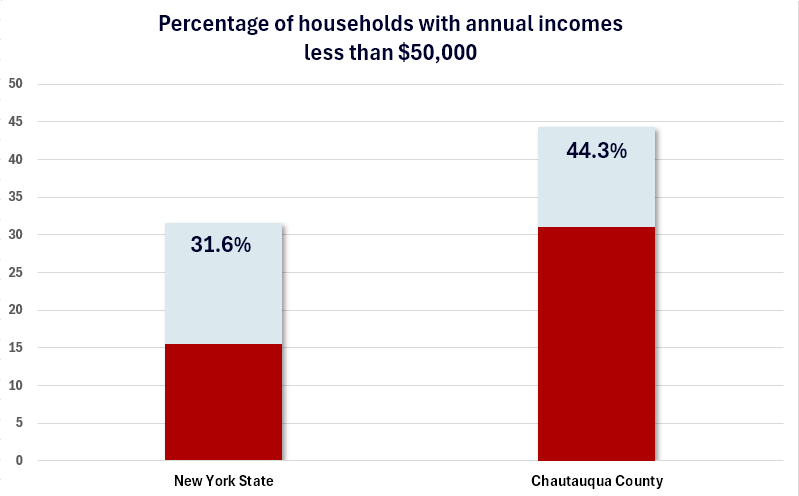

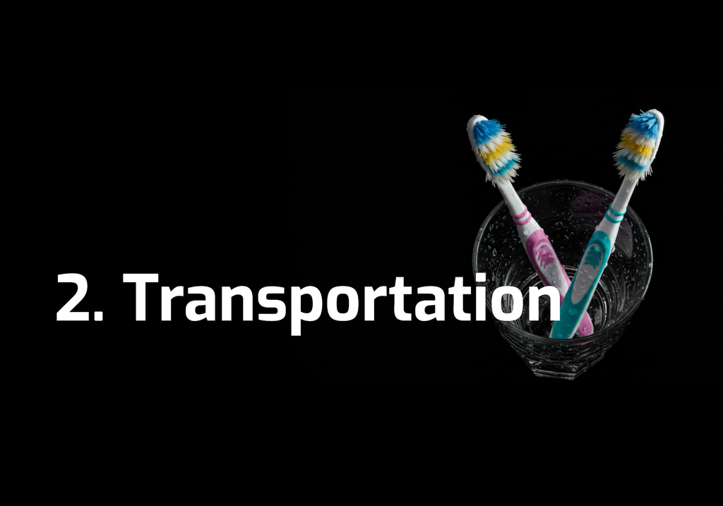

Let’s have a look at where dental offices are located in the county.

Now take a look at where dental offices are *not* located in the county.

The distances many county residents have to travel for dental care aren’t necessarily a problem…  
…unless you live in one of the county’s 11% of households without a vehicle.

Some census block groups have as many as 30-40 households without a vehicle…

…and others have even more - up to nearly 200 households.  
*(Darker colors = more households without a vehicle)*

56% (n=869) of respondents to the 2025 Chautauqua County Community Health Assessment Survey listed one or more reasons that they or someone in their household did not get the dental care that was needed, advised, or recommended.

Of these, 12% identified “Transportation - It was too hard to get there” as a reason.

Of note is that among those for whom transportation was reported as a barrier to receiving dental care, 25% reported household incomes *above* $50,000.

But even if transportation were *not* a barrier to accessing dental (and other) services for several thousand residents…  
… there remains a third major barrier to adequate oral healthcare for many, many people in our county:

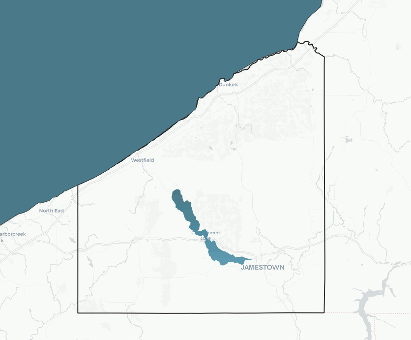

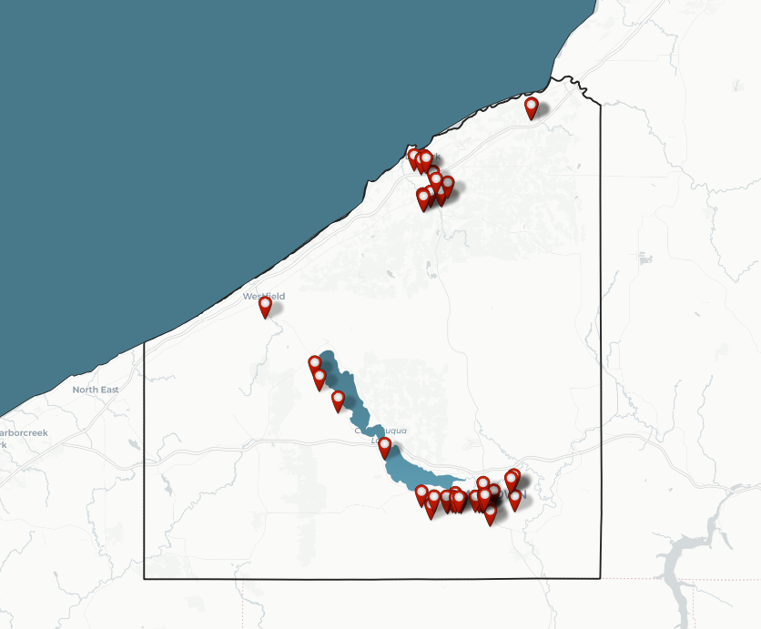

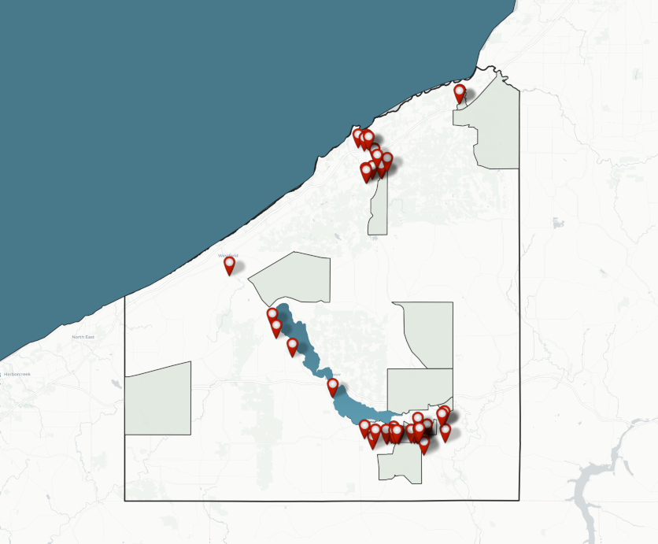

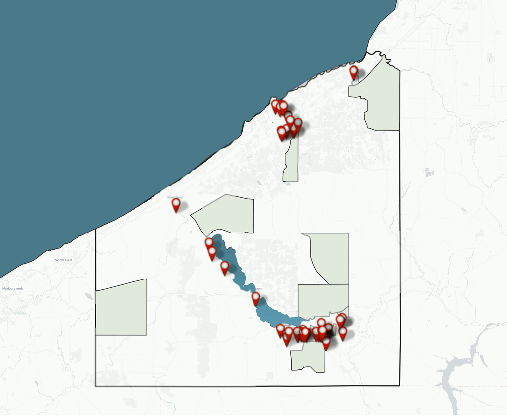

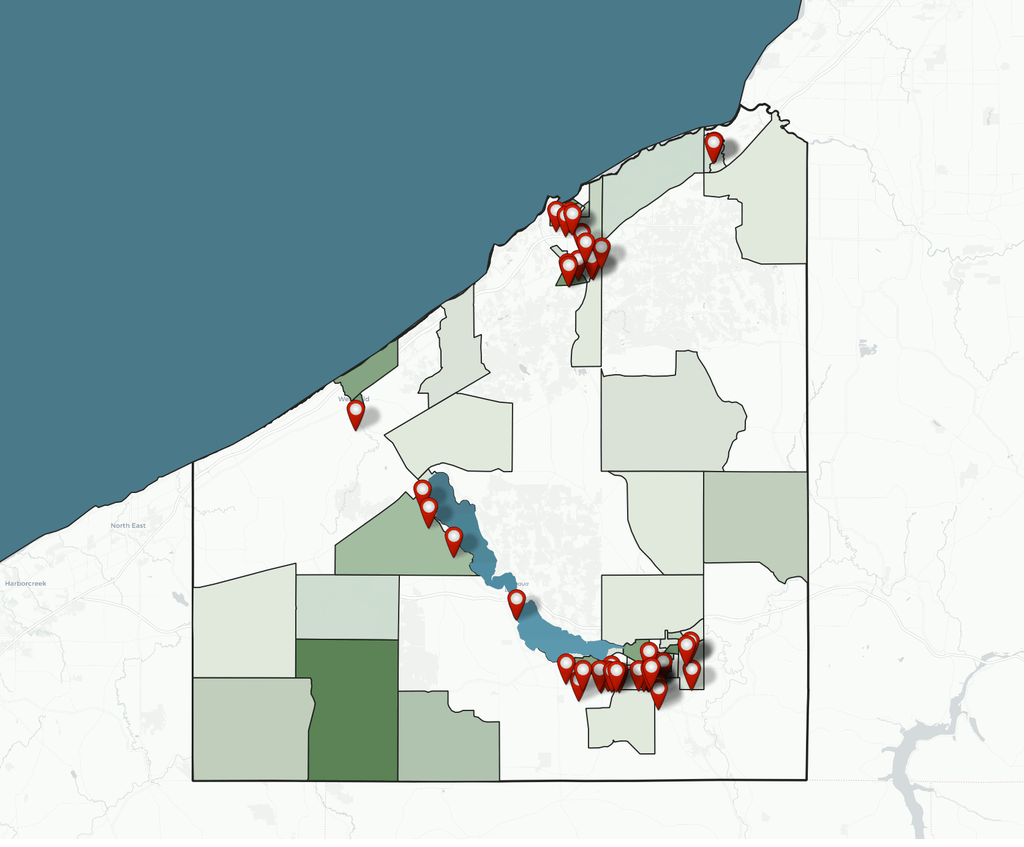

[Continue by clicking here!](https://chautauquacountyny.gov/sites/default/files/interactives/oral2.html)

[figure not shown]